# Predicting Boston’s Bikeshare Ridership

Ben Dodson

November 15, 2019

[figure not shown]

## Executive Summary

Using a predictive model, Boston can understand when bikeshare trip generations will be highest, and how they fluctuate overtime. Understanding which areas of Boston have the characteristics in place to support bikeshare stations has the potential to result in a more efficient and effective operation of the service. The model can predict the number of trips generated at each bikeshare station, within about 1.25 trips. The model has possible application’s in Boston’s transportation planning process. In areas where congestion is high and transit options are limited, this tool can quickly evaluate the success of a proposed station location. Additionally, in places where the model predicts usage should be high, but the observations show that usage is low, it would be worth investigating which factors are contributing to this. Possible factors could be station access, bike infrastructure in the vicinity, or a high population of bike owners. The model should be used as a tool to guide expansion and analysis of the system but not be used to replace these processes. The model works best when it is used as evidence to support intelligent and informed plans.

## Data

```r
June_2015 <- read.csv("~/MUSA507/Bike_Share/201506-hubway-tripdata.csv")
July_2015 <- read.csv("~/MUSA507/Bike_Share/201507-hubway-tripdata.csv")
August_2015 <- read.csv("~/MUSA507/Bike_Share/201508-hubway-tripdata.csv")
dat <- rbind(June_2015, July_2015, August_2015)
dat2 <- dat %>%
  mutate(interval60 = floor_date(ymd_hms(starttime), unit = "hour"),
         interval15 = floor_date(ymd_hms(starttime), unit = "15 mins"),
         week = week(interval60),
         dotw = wday(interval60, label=TRUE))
bostonCensus_suffolk <-
  get_acs(geography = "tract",
          variables = c("B01003_001", "B19013_001",
                        "B02001_002", "B08013_001",
                        "B08012_001", "B08301_001",
                        "B08301_010", "B01002_001"),
          year = 2015,
          state = "MA",
          geometry = TRUE,
          county=c("Suffolk"),
          output = "wide") %>%
  rename(Total_Pop =  B01003_001E,
         Med_Inc = B19013_001E,
         Med_Age = B01002_001E,
         White_Pop = B02001_002E,
         Travel_Time = B08013_001E,
         Num_Commuters = B08012_001E,
         Means_of_Transport = B08301_001E,
         Total_Public_Trans = B08301_010E) %>%
  select(Total_Pop, Med_Inc, White_Pop, Travel_Time,
         Means_of_Transport, Total_Public_Trans,
         Med_Age,
         GEOID, geometry) %>%
  mutate(Percent_White = White_Pop / Total_Pop,
         Mean_Commute_Time = Travel_Time / Total_Public_Trans,
         Percent_Taking_Public_Trans = Total_Public_Trans / Means_of_Transport)
bostonCensus_middlesex <-
  get_acs(geography = "tract",
          variables = c("B01003_001", "B19013_001",
                        "B02001_002", "B08013_001",
                        "B08012_001", "B08301_001",
                        "B08301_010", "B01002_001"),
          year = 2015,
          state = "MA",
          geometry = TRUE,
          county=c("Middlesex"),
          output = "wide") %>%
  rename(Total_Pop =  B01003_001E,
         Med_Inc = B19013_001E,
         Med_Age = B01002_001E,
         White_Pop = B02001_002E,
         Travel_Time = B08013_001E,
         Num_Commuters = B08012_001E,
         Means_of_Transport = B08301_001E,
         Total_Public_Trans = B08301_010E) %>%
  select(Total_Pop, Med_Inc, White_Pop, Travel_Time,
         Means_of_Transport, Total_Public_Trans,
         Med_Age,
         GEOID, geometry) %>%
  mutate(Percent_White = White_Pop / Total_Pop,
         Mean_Commute_Time = Travel_Time / Total_Public_Trans,
         Percent_Taking_Public_Trans = Total_Public_Trans / Means_of_Transport)
bostonCensus_norfolk <-
  get_acs(geography = "tract",
          variables = c("B01003_001", "B19013_001",
                        "B02001_002", "B08013_001",
                        "B08012_001", "B08301_001",
                        "B08301_010", "B01002_001"),
          year = 2015,
          state = "MA",
          geometry = TRUE,
          county=c("Norfolk"),
          output = "wide") %>%
  rename(Total_Pop =  B01003_001E,
         Med_Inc = B19013_001E,
         Med_Age = B01002_001E,
         White_Pop = B02001_002E,
         Travel_Time = B08013_001E,
         Num_Commuters = B08012_001E,
         Means_of_Transport = B08301_001E,
         Total_Public_Trans = B08301_010E) %>%
  select(Total_Pop, Med_Inc, White_Pop, Travel_Time,
         Means_of_Transport, Total_Public_Trans,
         Med_Age,
         GEOID, geometry) %>%
  mutate(Percent_White = White_Pop / Total_Pop,
         Mean_Commute_Time = Travel_Time / Total_Public_Trans,
         Percent_Taking_Public_Trans = Total_Public_Trans / Means_of_Transport)
bostonCensus <- rbind(bostonCensus_middlesex, bostonCensus_suffolk, bostonCensus_norfolk)
bostonTracts <-
  bostonCensus %>%
  as.data.frame() %>%
  distinct(GEOID, .keep_all = TRUE) %>%
  select(GEOID, geometry) %>%
  st_sf
dat_census <- st_join(dat2 %>%
                        filter(is.na(start.station.longitude) == FALSE &
                                 is.na(start.station.latitude) == FALSE &
                                 is.na(start.station.latitude) == FALSE &
                                 is.na(start.station.longitude) == FALSE) %>%
                        st_as_sf(., coords = c("start.station.longitude", "start.station.latitude"), crs = 4326),
                      bostonTracts %>%
                        st_transform(crs=4326),
                      join=st_intersects,
                      left = TRUE) %>%
  rename(Origin.Tract = GEOID) %>%
  mutate(start.station.longitude = unlist(map(geometry, 1)),
         start.station.latitude = unlist(map(geometry, 2)))%>%
  as.data.frame() %>%
  select(-geometry)%>%
  st_as_sf(., coords = c("end.station.longitude", "end.station.latitude"), crs = 4326) %>%
  st_join(., bostonTracts %>%
            st_transform(crs=4326),
          join=st_intersects,
          left = TRUE) %>%
  rename(Destination.Tract = GEOID)  %>%
  mutate(end.station.longitude = unlist(map(geometry, 1)),
         end.station.latitude = unlist(map(geometry, 2)))%>%
  as.data.frame() %>%
  select(-geometry)
```

```
## although coordinates are longitude/latitude, st_intersects assumes that they are planar
```

```
## although coordinates are longitude/latitude, st_intersects assumes that they are planar
## although coordinates are longitude/latitude, st_intersects assumes that they are planar
## although coordinates are longitude/latitude, st_intersects assumes that they are planar
```

```r
weather.Panel <-
  riem_measures(station = "BOS", date_start = "2015-06-01", date_end = "2015-08-31") %>%
  replace(is.na(.), 0) %>%
  mutate(interval60 = ymd_h(substr(valid,1,13))) %>%
  mutate(week = week(interval60),
         dotw = wday(interval60, label=TRUE)) %>%
  group_by(interval60) %>%
  summarize(Temperature = max(tmpf),
            Precipitation = sum(p01i),
            Wind_Speed = max(sknt)) %>%
  mutate(Temperature = ifelse(Temperature == 0, 42, Temperature))
```

Boston’s bikeshare program, Bluebikes, publishes usage data on a monthly basis. The most recent data availibile is from 2015. This analysis uses June-August data from 2015 to understand bikeshare usage throughout the summer. This data has been combined with Census data from the 3 Massachusetts counties (Suffolk, Norfolk, and Middlesex). The census data includes information about total population, median income, population that self-identifies as white, average time spent traveling, means of transport to work, population that took public transport to work, and median age. The model also uses historical weather data collected at Boston’s Logan Airport.

How many tracts are included in the 3 counties?

```r
nrow(bostonCensus)
```

```
## [1] 652
```

How many bikeshare stations are there?

```r
n_distinct(dat$start.station.id)
```

```
## [1] 140
```

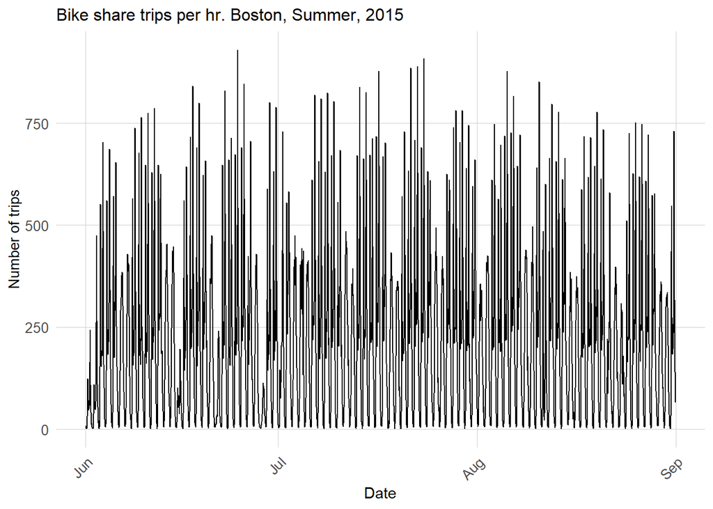

```r
ggplot(dat_census %>%
         group_by(interval60) %>%
         tally())+
  geom_line(aes(x = interval60, y = n))+
  labs(title="Bike share trips per hr. Boston, Summer, 2015",
       x="Date",
       y="Number of trips")+
  plotTheme
```

Notice drops at night and on weekends.

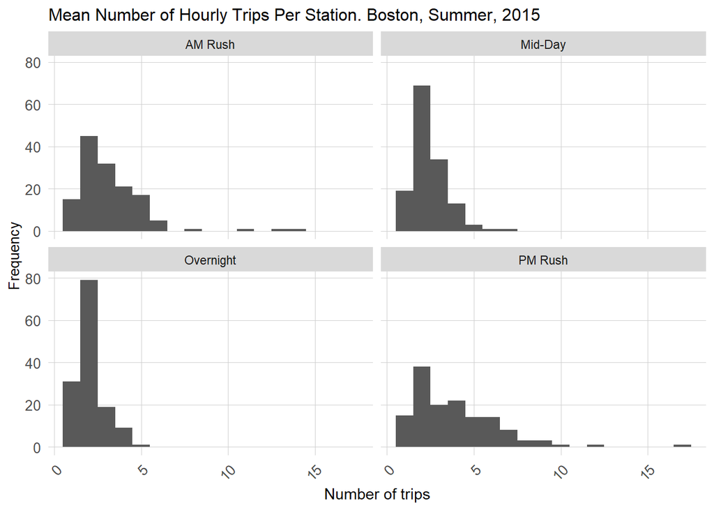

```r
dat_census %>%
  mutate(time_of_day = case_when(hour(interval60) < 7 | hour(interval60) > 18 ~ "Overnight",
                                 hour(interval60) >= 7 & hour(interval60) < 10 ~ "AM Rush",
                                 hour(interval60) >= 10 & hour(interval60) < 15 ~ "Mid-Day",
                                 hour(interval60) >= 15 & hour(interval60) <= 18 ~ "PM Rush"))%>%
  group_by(interval60, start.station.name, time_of_day) %>%
  tally()%>%
  group_by(start.station.name, time_of_day)%>%
  summarize(mean_trips = mean(n))%>%
  ggplot()+
  geom_histogram(aes(mean_trips), binwidth = 1)+
  labs(title="Mean Number of Hourly Trips Per Station. Boston, Summer, 2015",
       x="Number of trips",
       y="Frequency")+
  facet_wrap(~time_of_day)+
  plotTheme
```

Use during the AM and PM peak periods, is greater per station, than in the mid-day and overnight periods.

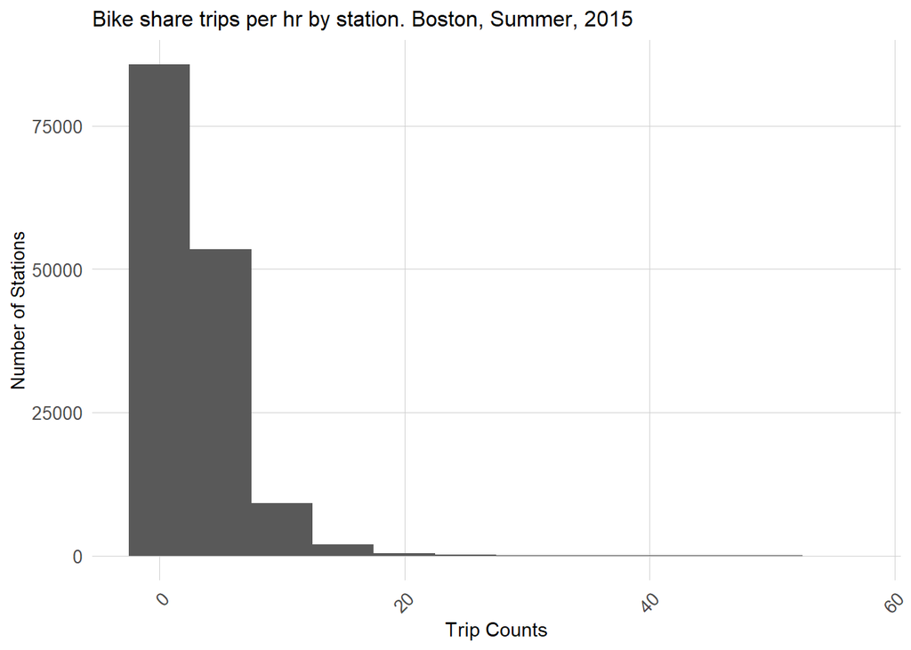

```r
ggplot(dat_census %>%
         group_by(interval60, start.station.name) %>%
         tally())+
  geom_histogram(aes(n), binwidth = 5)+
  labs(title="Bike share trips per hr by station. Boston, Summer, 2015",
       x="Trip Counts",
       y="Number of Stations")+
  plotTheme
```

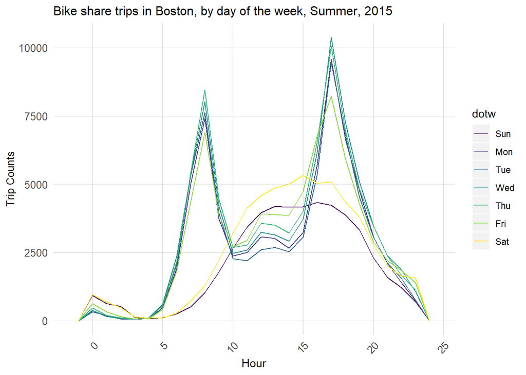

```r
ggplot(dat_census %>% mutate(hour = hour(starttime)))+
  geom_freqpoly(aes(hour, color = dotw), binwidth = 1)+
  labs(title="Bike share trips in Boston, by day of the week, Summer, 2015",
       x="Hour",
       y="Trip Counts")+
  plotTheme
```

During the weekday, trips were much greater during peak periods, while on the weekends, ridership was more dispersed throughout the daytime hours.

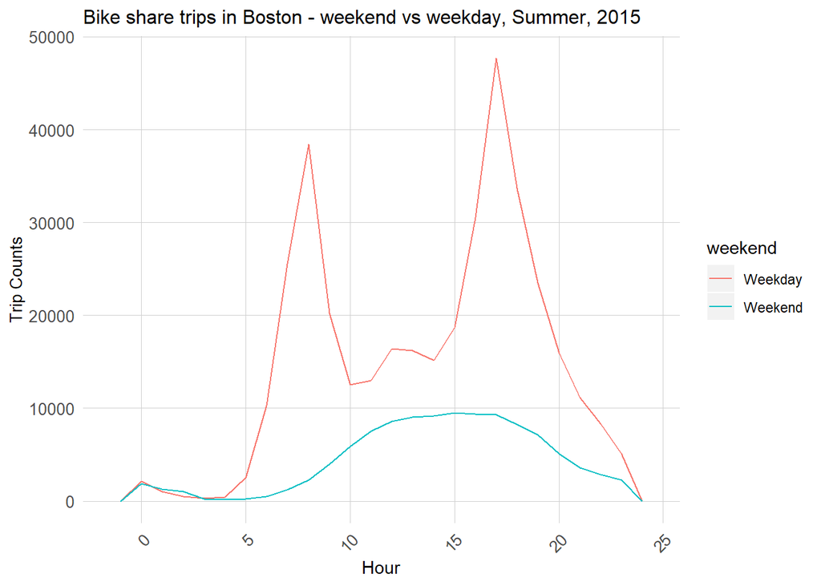

```r
ggplot(dat_census %>%
         mutate(hour = hour(starttime),
                weekend = ifelse(dotw %in% c("Sun", "Sat"), "Weekend", "Weekday")))+
  geom_freqpoly(aes(hour, color = weekend), binwidth = 1)+
  labs(title="Bike share trips in Boston - weekend vs weekday, Summer, 2015",
       x="Hour",
       y="Trip Counts")+
  plotTheme
```

Aggregating this by day of the week type confirms this assessment.

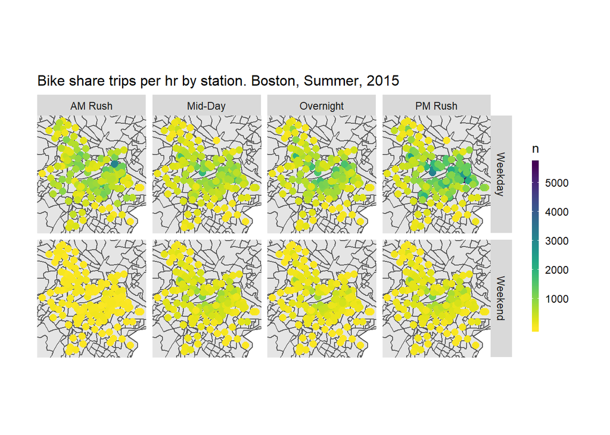

```r
ggplot()+
  geom_sf(data = bostonTracts %>%
            st_transform(crs=4326))+
  geom_point(data = dat_census %>%
               mutate(hour = hour(starttime),
                      weekend = ifelse(dotw %in% c("Sun", "Sat"), "Weekend", "Weekday"),
                      time_of_day = case_when(hour(interval60) < 7 | hour(interval60) > 18 ~ "Overnight",
                                              hour(interval60) >= 7 & hour(interval60) < 10 ~ "AM Rush",
                                              hour(interval60) >= 10 & hour(interval60) < 15 ~ "Mid-Day",
                                              hour(interval60) >= 15 & hour(interval60) <= 18 ~ "PM Rush"))%>%
               group_by(start.station.id, start.station.latitude, start.station.longitude, weekend, time_of_day) %>%
               tally(),
             aes(x=start.station.longitude, y = start.station.latitude, color = n),
             fill = "transparent", alpha = 1, size = 2.5)+
  scale_colour_viridis(direction = -1,
                       discrete = FALSE, option = "D")+
  ylim(min(dat_census$start.station.latitude), max(dat_census$start.station.latitude))+
  xlim(min(dat_census$start.station.longitude), max(dat_census$start.station.longitude))+
  facet_grid(weekend ~ time_of_day)+
  labs(title="Bike share trips per hr by station. Boston, Summer, 2015")+
  mapTheme
```

During the Weekday, the greatest number of trip origins are in Boston’s Central Business District whole on the weekend, it is much more dispersed throughout the service area.